# ML project 1 - final report

Michał Pastuszka, Karol Saputa, Mateusz Bąkała

15 - 04 - 2019

# 1 Problem description

## 1.1 Home Equity Line of Credit (HELOC) Dataset - classification

Our dataset consists of 10,460 anonymized data points of real homeowners credit applications. There are 24 variables of credit bureau data.

The aim of the project is to construct a model predicting RiskPerformance binary variable with two levels: Good or Bad basing on what we have.

# 2 Begginings

## 2.1 Introductory cleaning

The most important information that needs to be clarified beforehand is that the original dataset was randomly split into three separate datasubsets (training, tuning and testing) in 3:1:1 proportions. As the original data had nearly 10 000 observations, one can easily compute rough number of rows in each datasubset.

We begin with reading .csv file with training set.

```r
df <- readr::read_csv("dataset/df_train.csv", col_types = cols(
  RiskPerformance = col_factor(levels = c("Good", "Bad")),
  ExternalRiskEstimate = col_double(),
  MSinceOldestTradeOpen = col_double(),
  MSinceMostRecentTradeOpen = col_double(),
  AverageMInFile = col_double(),
  NumSatisfactoryTrades = col_double(),
  NumTrades60Ever2DerogPubRec = col_double(),
  NumTrades90Ever2DerogPubRec = col_double(),
  PercentTradesNeverDelq = col_double(),
  MSinceMostRecentDelq = col_double(),
  MaxDelq2PublicRecLast12M = col_double(),
  MaxDelqEver = col_double(),
  NumTotalTrades = col_double(),
  NumTradesOpeninLast12M = col_double(),
  PercentInstallTrades = col_double(),
  MSinceMostRecentInqexcl7days = col_double(),
  NumInqLast6M = col_double(),
  NumInqLast6Mexcl7days = col_double(),
  NetFractionRevolvingBurden = col_double(),
  NetFractionInstallBurden = col_double(),
  NumRevolvingTradesWBalance = col_double(),
  NumInstallTradesWBalance = col_double(),
  NumBank2NatlTradesWHighUtilization = col_double(),
  PercentTradesWBalance = col_double()
))

df_testraw <- readr::read_csv("dataset/df_test.csv", col_types = cols(
  ExternalRiskEstimate = col_double(),
  MSinceOldestTradeOpen = col_double(),
  MSinceMostRecentTradeOpen = col_double(),
  AverageMInFile = col_double(),
  NumSatisfactoryTrades = col_double(),
  NumTrades60Ever2DerogPubRec = col_double(),
  NumTrades90Ever2DerogPubRec = col_double(),
  PercentTradesNeverDelq = col_double(),
  MSinceMostRecentDelq = col_double(),
  MaxDelq2PublicRecLast12M = col_double(),
  MaxDelqEver = col_double(),
  NumTotalTrades = col_double(),
  NumTradesOpeninLast12M = col_double(),
  PercentInstallTrades = col_double(),
  MSinceMostRecentInqexcl7days = col_double(),
  NumInqLast6M = col_double(),
  NumInqLast6Mexcl7days = col_double(),
  NetFractionRevolvingBurden = col_double(),
  NetFractionInstallBurden = col_double(),
  NumRevolvingTradesWBalance = col_double(),
  NumInstallTradesWBalance = col_double(),
  NumBank2NatlTradesWHighUtilization = col_double(),
  PercentTradesWBalance = col_double()
))
#source("models/read_dfs.R")
```

## 2.2 Baseline model

Firstly, we would like to present the effects of `cforest` model trained on the data without any modifications, preprocessing, feature engineering for further refeferences. `cforest` is a random forest model using different implementation (base learners, aggregation schema) than “randomForest”. Moreover it is able to cope with a missing data what was important at that level.

```r
task = makeClassifTask(id = "task", data = df, target = "RiskPerformance")
lrn = makeLearner("classif.cforest", predict.type = "prob", par.vals=list())
train_ <- train(lrn, task)

prediction <- predict(train_, newdata = df_testraw, measures = list(acc, auc, tnr, tpr, ppv, f1))
calculateROCMeasures(prediction) -> result
calculateConfusionMatrix(prediction)
```

```
##         predicted
## true     Good Bad -err.-
##   Good    669 329    329
##   Bad     258 836    258
##   -err.-  258 329    587
```

```r
auc_score <- measureAUC(prediction$data$prob.Good, truth = prediction$data$truth, positive = "Good")
acc_score <- result$measures$acc
paste0("AUC score ", auc_score)
```

```
## [1] "AUC score 0.790708015665701"
```

```r
paste0("ACC score ", acc_score)
```

```
## [1] "ACC score 0.719407265774379"
```

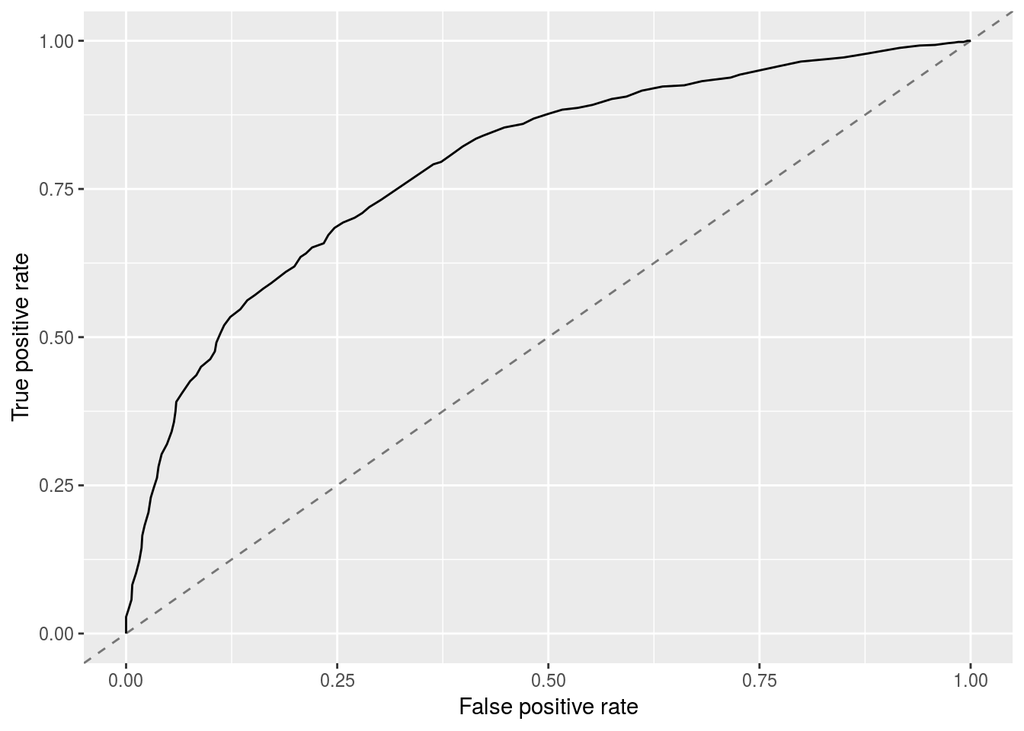

```r
plotROCCurves(generateThreshVsPerfData(prediction, measures = list(fpr, tpr)))
```

# 3 Features & cleaning

## 3.1 Missing data

We didn’t use the obvious choice of checking missing data statistics with built-in functions of DataExplorer library because we knew that NA-s are encoded in this dataset differently. To clarify the issue, all non-missing data here is expressed with non-negative numbers, while there are three kinds of NA-s, each having its own negative value of -7, -8 or -9 and different meaning. They also appear at different frequencies thorough the variables, though they actually sum up to similar number each.

It may be valuable to take a look at the distributions of NA-s across variables, so there’s a plot to help with illustrating the issue.

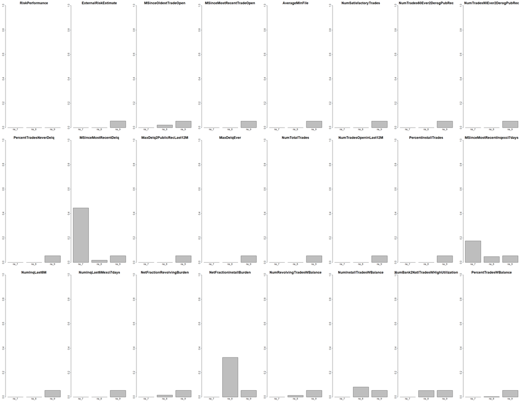

NA-s split by type and variable

Now that we have seen a graphical representation, let’s move on to the description, which will say us a bit more about the meaning of each NA code. As we said before, -9 means no credit history and/or score available and can be considered the “true” NA, as it is a typical example of no data. -8 is used for cases when there is no usable data for this record, e.g. if this person was inactive for a year. Then, -7 is used when condition is not met, as in someone have never had an inquiry before the last 7 days (second row, last column in the plot above) and we ask for the days since such an event.

There are rows that contain only -9s (not counting target column), so it’s not very informative. Let’s drop these rows.

```r
#backup
df_ <- df
df_testraw_ <- df_testraw
df <- df[!apply(df[, -1], 1, function(x) all(x == -9)), ]
df_testraw <- df_testraw[!apply(df_testraw[, -1], 1, function(x) all(x == -9)), ]
```

Now we need to check in which columns there are -9s left.

```r
names(which(apply(df[, -1], 2, function(x) any(x == -9))))
```

```
## [1] "ExternalRiskEstimate"
```

Luckily, only one column contains -9s after our first cleaning step. These are records for which nobody ever made a risk estimate. They are not very numerous (only 5 cases, actually, less than 0.1% of the data), so we can make an assumption that these estimates would be somewhere around median. The code below substitutes median value of this column for aforementioned cases.

```r
df[df$ExternalRiskEstimate == -9, 2] <- median(df$ExternalRiskEstimate, na.rm = TRUE)
df_testraw[df_testraw$ExternalRiskEstimate == -9, 2] <- median(df$ExternalRiskEstimate, na.rm = TRUE)
```

### 3.1.1 Check of the score

```r
task <- makeClassifTask(id = "task", data = df, target = "RiskPerformance")
rt <- run_learner(makeLearner("classif.cforest", predict.type = "prob", par.vals=list()))
#knitr::kable(c(rt, "acc_old" = acc_score, "auc_old" = auc_score))
knitr::kable(data.frame("base" = c(auc_score, acc_score), "new" = rt, row.names = c("auc  ", "acc  "))) %>% kable_styling()
```

|  | base | new |
| --- | --- | --- |
| auc | 0.7907080 | 0.7971565 |
| acc | 0.7194073 | 0.7295661 |

We can see an improvement both in AUC and ACC.

## 3.2 Dropping columns

If we look closely and thoroughly, we can find two pairs of columns with high correlation values. Their names are also an indicator of correlation. Decision was made to:

- exclude NumTrades60Ever2DerogPubRec and leave NumTrades90Ever2DerogPubRec (0.897 correlation),
- exclude NumInqLast6M and leave NumInqLast6Mexcl7days (0.992 correlation).

```r
df <- drop_columns(df, c("NumTrades60Ever2DerogPubRec", "NumInqLast6M"))
df_testraw <- drop_columns(df_testraw, c("NumTrades60Ever2DerogPubRec", "NumInqLast6M"))
```

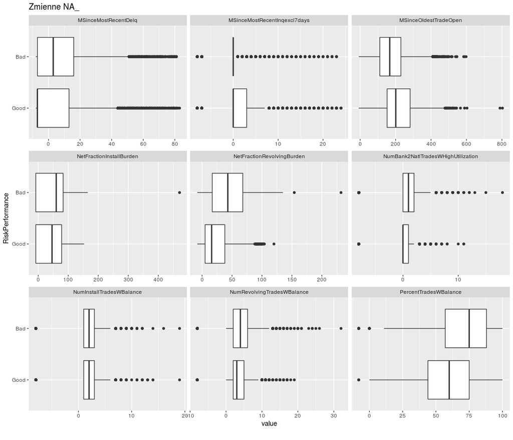

Impact of incomplete variables on target

## 3.3 Conversion of a column with multiple NA types into two columns

Encoding of missing data used in our dataset is, honestly speaking, quite inconvenient. We decided to remedy that by splitting necessary columns into two separate ones:

- old numerical column with one general NA
- new logical column dependent on type of NA

The second column is created to inform about the type of missingness. As such, we encoded it with FALSE for -7s, as it indicates impossibility of finding requested entity, and TRUE for -8s and non-missing data. We would also set NAs in this column for -9s, but there were none left by this time. Quite obviously, we dropped this column every time it contained only truths, as it would tell us nothing really.

This type of conversion was applied on two columns with mixed NAs – MSinceMostRecentInqexcl7days and MSinceMostRecentDelq – and six more with -8s only.

**Before:**

| MSinceMostRecentDelq | MSinceMostRecentInqexcl7days |
| --- | --- |
| 22 | -7 |
| -7 | 0 |
| 0 | 2 |
| 32 | 0 |
| -7 | 0 |
| 3 | 4 |

```r
df <- na_process(df, "MSinceMostRecentDelq", "HadDelq")
df <- na_process(df, "MSinceMostRecentInqexcl7days", "HadInqexcl7days")
df <- na_process(df, "MSinceOldestTradeOpen")
df <- na_process(df, "NetFractionRevolvingBurden")
df <- na_process(df, "NetFractionInstallBurden")
df <- na_process(df, "NumRevolvingTradesWBalance")
df <- na_process(df, "NumBank2NatlTradesWHighUtilization")
df <- na_process(df, "PercentTradesWBalance")

df_testraw <- na_process(df_testraw, "MSinceMostRecentDelq", "HadDelq")
df_testraw <- na_process(df_testraw, "MSinceMostRecentInqexcl7days", "HadInqexcl7days")
df_testraw <- na_process(df_testraw, "MSinceOldestTradeOpen")
df_testraw <- na_process(df_testraw, "NetFractionRevolvingBurden")
df_testraw <- na_process(df_testraw, "NetFractionInstallBurden")
df_testraw <- na_process(df_testraw, "NumRevolvingTradesWBalance")
df_testraw <- na_process(df_testraw, "NumBank2NatlTradesWHighUtilization")
df_testraw <- na_process(df_testraw, "PercentTradesWBalance")
```

**After:**

| MSinceMostRecentDelq | HadDelq | MSinceMostRecentInqexcl7days | HadInqexcl7days |
| --- | --- | --- | --- |
| 22 | TRUE | NA | FALSE |
| NA | FALSE | 0 | TRUE |
| 0 | TRUE | 2 | TRUE |
| 32 | TRUE | 0 | TRUE |
| NA | FALSE | 0 | TRUE |
| 3 | TRUE | 4 | TRUE |

### 3.3.1 Check of the score

```r
df$HadDelq <- as.integer(df$HadDelq)
df$HadInqexcl7days <- as.integer(df$HadInqexcl7days)
df_testraw$HadDelq <- as.integer(df_testraw$HadDelq)
df_testraw$HadInqexcl7days <- as.integer(df_testraw$HadInqexcl7days)

task <- makeClassifTask(id = "taskk", data = df, target = "RiskPerformance")
rt <- run_learner(makeLearner("classif.cforest", predict.type = "prob", par.vals=list()))
knitr::kable(data.frame("base" = c(auc_score, acc_score), "new" = rt, row.names = c("auc  ", "acc  "))) %>% kable_styling()
```

|  | base | new |
| --- | --- | --- |
| auc | 0.7907080 | 0.7995256 |
| acc | 0.7194073 | 0.7295661 |

The results are slightly better.

## 3.4 One-hot encoding

```r
df$MaxDelq2PublicRecLast12M <- as.factor(df$MaxDelq2PublicRecLast12M)
df_testraw$MaxDelq2PublicRecLast12M <- as.factor(df_testraw$MaxDelq2PublicRecLast12M)


df$MaxDelqEver <- as.factor(df$MaxDelqEver)
df_testraw$MaxDelqEver <- as.factor(df_testraw$MaxDelqEver)

df <- mlr::createDummyFeatures(df, target = "RiskPerformance")
df_testraw <- mlr::createDummyFeatures(df_testraw, target = "RiskPerformance")
```

## 3.5 NA imputation

As many models do not support NA’s, we decided to prepare an additional version of data using imputation from the `vtreat` package.

```r
treatment <- design_missingness_treatment(df, varlist = colnames(df)[-1])
df_imputed <- prepare(treatment, df)
df_testimputed <- prepare(treatment, df_testraw)
```

### 3.5.1 Check of the score

```r
task <- makeClassifTask(id = "taskk", data = df, target = "RiskPerformance")
rt <- run_learner(makeLearner("classif.cforest", predict.type = "prob", par.vals=list()))
knitr::kable(data.frame("base" = c(auc_score, acc_score), "new" = rt, row.names = c("auc  ", "acc  "))) %>% kable_styling()
```

|  | base | new |
| --- | --- | --- |
| auc | 0.7907080 | 0.7984839 |
| acc | 0.7194073 | 0.7275479 |

The results are still better than the baseline model. However, after one-hot encoding scores got worse.

# 4 Model selection

After doing some preprocessing on the data and preparing a version of data without NA’s for models that can’t handle them, we decided to see how will different algorithms perform. We decided to test:

- `J48` decision tree,
- `LiblineaRL1LogReg` logistic regression,
- `lssvm` support vector machine,
- `randomForestSRC` random forest,
- `xgboost` gradient boosting,
- `bartMachine` Bayesian Additive Regresion Trees - a more complex model.

As our data contained a column ExternalRiskEstimate, which contained external predictions about the target and was highly correlated with it, we decided to test the models with and without this column. We also wanted to see, how accurately can we predict basing exclusively on this column.

```r
task <- makeClassifTask(id = "task", data = df_train, target = "RiskPerformance")



run_learner <- function(lrn) {
  train_ <- train(lrn, task)
  prediction <- predict(train_, newdata = df_test)
  calculateROCMeasures(prediction) -> result
  calculateConfusionMatrix(prediction)
  score <- c(auc = measureAUC(prediction$data$prob.Good, truth = prediction$data$truth, positive = "Good"),
             acc = result$measures$acc)
  print(score)
  return(prediction)
}

#:# bartMachine #:#
bart <- run_learner(makeLearner("classif.bartMachine", predict.type = "prob", par.vals=list(num_trees=120)))
# > auc_score
# [1] 0.806246
# > acc_score
# [1] 0.7386478

#:# J48 #:#
j48 <- run_learner(makeLearner("classif.J48", predict.type = "prob"))
# > auc_score
# [1] 0.6471645
# > acc_score
# [1] 0.6226034

#:# LiblineaRL1LogReg #:#
LiblineaRL1LogReg <- run_learner(makeLearner("classif.LiblineaRL1LogReg", predict.type = "prob"))
# > auc_score
# [1] 0.8009499
# > acc_score
# [1] 0.7336024

#:# lssvm #:#
lssvm <- run_learner(makeLearner("classif.lssvm"))
# > auc_score
# [1] NA
# > acc_score
# [1] 0.7336024

#:# randomForestSRC #:#
randomForestSRC <- run_learner(makeLearner("classif.randomForestSRC", predict.type = "prob", par.vals = list(ntree= 150)))
# > auc_score
# [1] 0.7960848
# > acc_score
# [1] 0.7305752

#:# svm #:#
svm <- run_learner(makeLearner("classif.svm"))
# > auc_score
# [1] NA
# > acc_score
# [1] 0.734107

#:# xgboost #:#
xgboost <- run_learner(makeLearner("classif.xgboost", predict.type = "prob", par.vals = list(
  objective = "binary:logistic",
  eval_metric = "error",
  nrounds = 200
)))
# > auc_score
# [1] 0.7760138
# > acc_score
# [1] 0.7083754
```

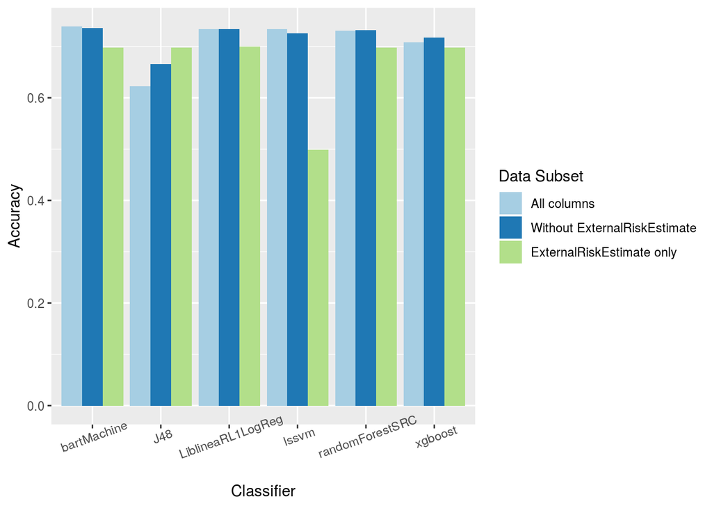

And here are the ROC curves for tested models excluding svm as it does not return probability:

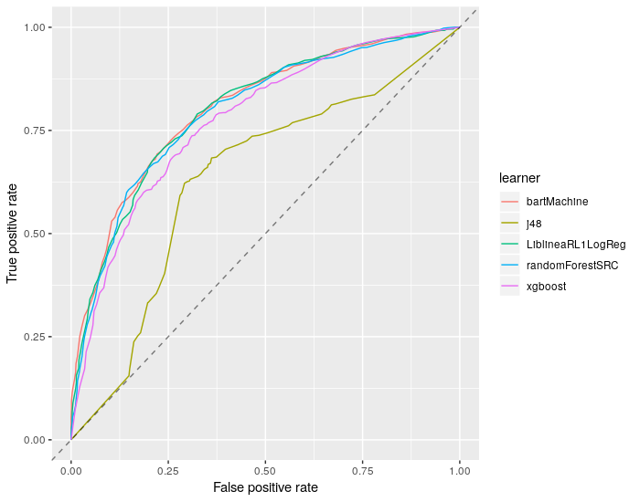

ROC of models

As we can see all of the models except for the decision tree achieve similar results.

# 5 Hyperparameters tuning

```r
tasktune <- makeClassifTask(id = "task2", data = df_tune, target = "RiskPerformance")

barttune <- tuneParams(learner = makeLearner("classif.bartMachine"), task = tasktune, resampling = makeResampleDesc("CV", iters = 3),
                       measures = list(mlr::auc), control = makeTuneControlRandom(maxit = 50),
                       par.set = makeParamSet(
                         makeNumericParam("beta", lower=0.5, upper=10),
                         makeNumericParam("q", lower=0, upper=1),
                         makeNumericParam("k", lower=0.5, upper=10)))

lssvtune <- tuneParams(learner = makeLearner("classif.lssvm"), task = tasktune, resampling = makeResampleDesc("CV", iters = 3),
                     measures = list(mlr::acc), control = makeTuneControlRandom(maxit = 100),
                     par.set = makeParamSet(
                       makeNumericParam("sigma", lower=0.01, upper=10),
                       makeNumericParam("tau", lower=0.01, upper=10)))
svtune <- tuneParams(learner = makeLearner("classif.svm"), task = tasktune, resampling = makeResampleDesc("CV", iters = 3),
                     measures = list(mlr::acc), control = makeTuneControlRandom(maxit = 100),
                     par.set = makeParamSet(
                       makeNumericParam("gamma", lower=0.01, upper=10),
                       makeNumericParam("cost", lower=0.01, upper=10)))

lrn <- makeLearner("classif.randomForestSRC", predict.type = "prob", par.vals = list(ntree= 150))
treetune <- tuneParams(learner = lrn, task = tasktune, resampling = makeResampleDesc("CV", iters = 3),
                       measures = list(mlr::auc), control = makeTuneControlRandom(maxit = 25),
                       par.set = makeParamSet(
                         makeDiscreteParam("nodesize", 1:10),
                         makeDiscreteParam("nodedepth", -1:10)))

logregtune <- tuneParams(learner = makeLearner("classif.LiblineaRL1LogReg"), task = tasktune, resampling = makeResampleDesc("CV", iters = 3), measures = list(mlr::acc), control = makeTuneControlMBO(), par.set =
                       makeParamSet(makeNumericParam("cost", lower=1, upper=20),makeNumericParam("epsilon", lower=0.001, upper=1)))
```

```r
tune_scores <- data.frame(beforeACC = c(0.7386478, 0.7336024, 0.734107, 0.7305752, 0.7336024),
                          afterACC = c(0.7371342, 0.721998, 0.7174571, 0.7320888, 0.7341070),
                          beforeAUC = c(0.806246, NA, NA, 0.7960848, 0.8009499),
                          afterAUC = c(0.8042361, NA, NA, 0.7994746, 0.8029628),
                          row.names = c("bartMachine", "lssvm", "svm", "randomForestSRC", "LiblineaRL1LogReg"))
knitr::kable(tune_scores) %>% kable_styling()
```

|  | beforeACC | afterACC | beforeAUC | afterAUC |
| --- | --- | --- | --- | --- |
| bartMachine | 0.7386478 | 0.7371342 | 0.8062460 | 0.8042361 |
| lssvm | 0.7336024 | 0.7219980 | NA | NA |
| svm | 0.7341070 | 0.7174571 | NA | NA |
| randomForestSRC | 0.7305752 | 0.7320888 | 0.7960848 | 0.7994746 |
| LiblineaRL1LogReg | 0.7336024 | 0.7341070 | 0.8009499 | 0.8029628 |

# 6 Models learning time

We decided to compare not only performance, but also the time it takes for the models to learn and make predictions.

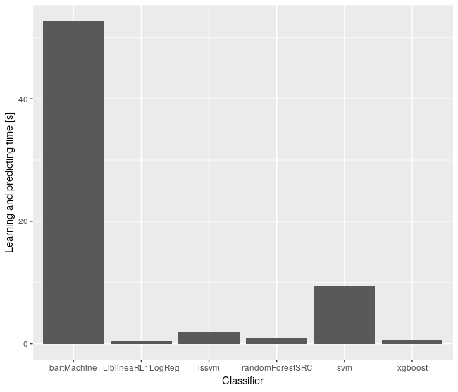

We can clearly see that although `bartMachine` is one of the best performing models, it’s also much slower than them whereas `LiblineaRL1LogReg` is the fastest, while still being one of the most accurate ones.

# 7 Models exploration

```r
custom_predict_function <- function(object, newdata) {
  pred <- predict(object, newdata = newdata)
  response <- pred$data[, 3]
  return(response)
}

tsk <- makeClassifTask("riskPerf", data = df_train, target = "RiskPerformance")
# predict.type = "prob" is necessary

perf <- list()
vi <- list()
pdp <- list()
# should be more of these learners, but it was faster this way at development phase
learner_vector <- c("classif.LiblineaRL1LogReg", "classif.randomForestSRC", "classif.bartMachine", "classif.xgboost")
for (learner in learner_vector) {
  lrn <- makeLearner(learner, predict.type = "prob")
  trn <- train(lrn, tsk)

  explainer <- explain(trn, data = df_test, y = as.numeric(df_test$RiskPerformance == "Good"),
                       label = trn$learner$id, predict_function = custom_predict_function)
  message(paste0(learner, " explained."))

  perf[[learner]] <- model_performance(explainer)
  message(paste0(learner, " performed."))

  vi[[learner]] <- variable_importance(explainer, loss_function = loss_root_mean_square)
  message(paste0(learner, " has variables importanted."))

  pdp[[learner]] <- variable_response(explainer, variable = "ExternalRiskEstimate", type = "pdp")
  message(paste0(learner, " has variables responded."))
}

plot(perf[[learner_vector[1]]],
     perf[[learner_vector[2]]],
     perf[[learner_vector[3]]],
     perf[[learner_vector[4]]])

plot(vi[[learner_vector[1]]],
     vi[[learner_vector[2]]],
     vi[[learner_vector[3]]],
     vi[[learner_vector[4]]])

plot(pdp[[learner_vector[1]]],
     pdp[[learner_vector[2]]],
     pdp[[learner_vector[3]]],
     pdp[[learner_vector[4]]])
```

## 7.1 Distribution of residual

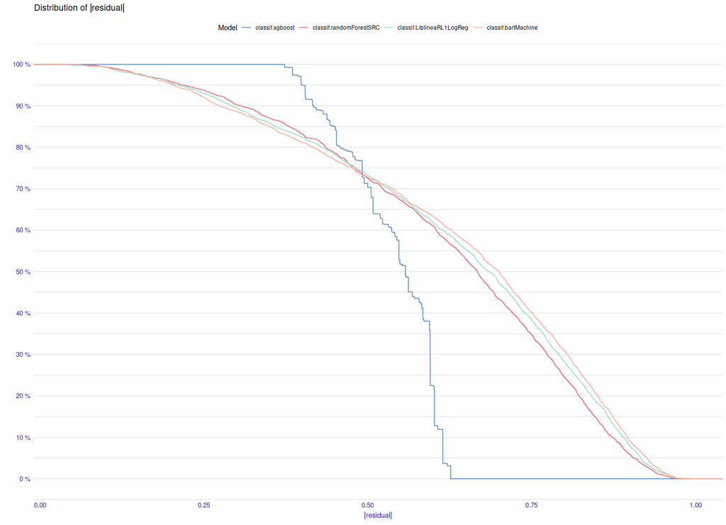

## 7.2 Variable response

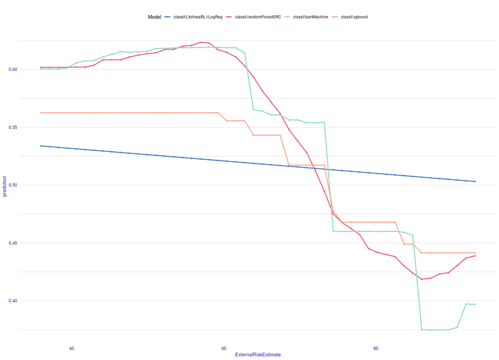

## 7.3 Variable importance

Two most important variables for `LiblineaRL1LogReg`:

- MaxDelqEver - Max Delinquency Ever
- PercentTradesWBalance - Percent Trades with Balance

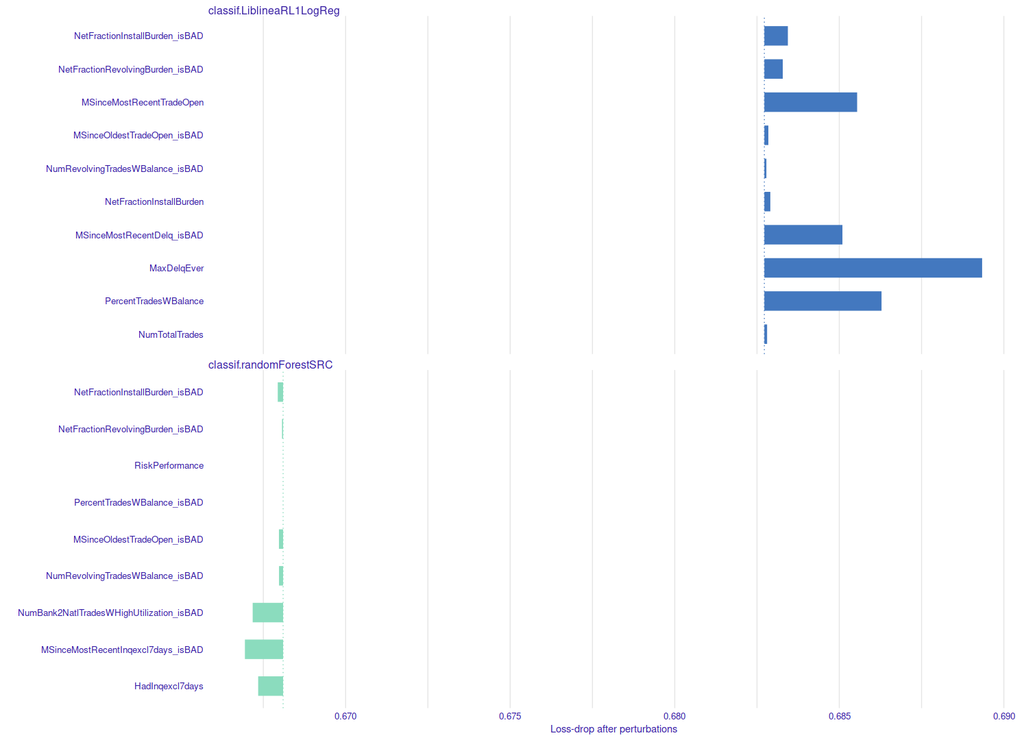

# 8 Final model summary

Taking into consideration computation time and AUC, ACC metrics we choose `LiblineaRL1LogReg` as the most preferrable model with final AUC at the level of $0.80$ which is $1.54\%$ better than the baseline model.